# Risk Factor Analysis

## Outcome Variable

**Outcome Variable:** y_rate_haz

## Predictor Variables

**Intervention Variable:** parity

**Adjustment Set:**

- arm
- W_mage
- meducyrs
- feducyrs
- W_mhtcm
- W_mwtkg
- W_mbmi
- vagbrth
- single
- delta_W_mage
- delta_meducyrs
- delta_feducyrs
- delta_W_mhtcm
- delta_W_mwtkg
- delta_W_mbmi
- delta_vagbrth
- delta_single

## Stratifying Variables

The analysis was stratified on these variable(s):

- agecat
- studyid
- country

## Data Summary

| agecat | studyid | country | parity | n_cell | n |
| --- | --- | --- | --- | --- | --- |
| 0-3 months | COHORTS | GUATEMALA | 1 | 93 | 728 |
| 0-3 months | COHORTS | GUATEMALA | 2 | 111 | 728 |
| 0-3 months | COHORTS | GUATEMALA | 3+ | 524 | 728 |
| 0-3 months | COHORTS | INDIA | 1 | 671 | 4021 |
| 0-3 months | COHORTS | INDIA | 2 | 1015 | 4021 |
| 0-3 months | COHORTS | INDIA | 3+ | 2335 | 4021 |
| 0-3 months | GMS-Nepal | NEPAL | 1 | 137 | 509 |
| 0-3 months | GMS-Nepal | NEPAL | 2 | 129 | 509 |
| 0-3 months | GMS-Nepal | NEPAL | 3+ | 243 | 509 |
| 0-3 months | JiVitA-3 | BANGLADESH | 1 | 6338 | 19878 |
| 0-3 months | JiVitA-3 | BANGLADESH | 2 | 6881 | 19878 |
| 0-3 months | JiVitA-3 | BANGLADESH | 3+ | 6659 | 19878 |
| 0-3 months | Keneba | GAMBIA | 1 | 130 | 1145 |
| 0-3 months | Keneba | GAMBIA | 2 | 113 | 1145 |
| 0-3 months | Keneba | GAMBIA | 3+ | 902 | 1145 |
| 0-3 months | PROVIDE | BANGLADESH | 1 | 242 | 640 |
| 0-3 months | PROVIDE | BANGLADESH | 2 | 226 | 640 |
| 0-3 months | PROVIDE | BANGLADESH | 3+ | 172 | 640 |
| 0-3 months | SAS-CompFeed | INDIA | 1 | 344 | 1261 |
| 0-3 months | SAS-CompFeed | INDIA | 2 | 298 | 1261 |
| 0-3 months | SAS-CompFeed | INDIA | 3+ | 619 | 1261 |
| 0-3 months | ZVITAMBO | ZIMBABWE | 1 | 3100 | 7981 |
| 0-3 months | ZVITAMBO | ZIMBABWE | 2 | 2478 | 7981 |
| 0-3 months | ZVITAMBO | ZIMBABWE | 3+ | 2403 | 7981 |
| 3-6 months | COHORTS | GUATEMALA | 1 | 107 | 805 |
| 3-6 months | COHORTS | GUATEMALA | 2 | 114 | 805 |
| 3-6 months | COHORTS | GUATEMALA | 3+ | 584 | 805 |
| 3-6 months | COHORTS | INDIA | 1 | 675 | 4069 |
| 3-6 months | COHORTS | INDIA | 2 | 1042 | 4069 |
| 3-6 months | COHORTS | INDIA | 3+ | 2352 | 4069 |

[output cut: 156 more lines]

The following strata were considered:

- agecat: 0-3 months, studyid: COHORTS, country: GUATEMALA
- agecat: 0-3 months, studyid: COHORTS, country: INDIA
- agecat: 0-3 months, studyid: GMS-Nepal, country: NEPAL
- agecat: 0-3 months, studyid: JiVitA-3, country: BANGLADESH
- agecat: 0-3 months, studyid: Keneba, country: GAMBIA
- agecat: 0-3 months, studyid: PROVIDE, country: BANGLADESH
- agecat: 0-3 months, studyid: SAS-CompFeed, country: INDIA
- agecat: 0-3 months, studyid: ZVITAMBO, country: ZIMBABWE
- agecat: 12-15 months, studyid: COHORTS, country: GUATEMALA
- agecat: 12-15 months, studyid: GMS-Nepal, country: NEPAL
- agecat: 12-15 months, studyid: Keneba, country: GAMBIA
- agecat: 12-15 months, studyid: PROVIDE, country: BANGLADESH
- agecat: 12-15 months, studyid: SAS-CompFeed, country: INDIA
- agecat: 12-15 months, studyid: SAS-FoodSuppl, country: INDIA
- agecat: 12-15 months, studyid: TanzaniaChild2, country: TANZANIA, UNITED REPUBLIC OF
- agecat: 12-15 months, studyid: ZVITAMBO, country: ZIMBABWE
- agecat: 15-18 months, studyid: COHORTS, country: GUATEMALA
- agecat: 15-18 months, studyid: GMS-Nepal, country: NEPAL
- agecat: 15-18 months, studyid: Keneba, country: GAMBIA
- agecat: 15-18 months, studyid: PROVIDE, country: BANGLADESH
- agecat: 15-18 months, studyid: SAS-CompFeed, country: INDIA
- agecat: 15-18 months, studyid: SAS-FoodSuppl, country: INDIA
- agecat: 15-18 months, studyid: TanzaniaChild2, country: TANZANIA, UNITED REPUBLIC OF
- agecat: 15-18 months, studyid: ZVITAMBO, country: ZIMBABWE
- agecat: 18-21 months, studyid: COHORTS, country: GUATEMALA
- agecat: 18-21 months, studyid: GMS-Nepal, country: NEPAL
- agecat: 18-21 months, studyid: Keneba, country: GAMBIA
- agecat: 18-21 months, studyid: PROVIDE, country: BANGLADESH
- agecat: 18-21 months, studyid: TanzaniaChild2, country: TANZANIA, UNITED REPUBLIC OF
- agecat: 18-21 months, studyid: ZVITAMBO, country: ZIMBABWE
- agecat: 21-24 months, studyid: COHORTS, country: GUATEMALA
- agecat: 21-24 months, studyid: GMS-Nepal, country: NEPAL
- agecat: 21-24 months, studyid: Keneba, country: GAMBIA
- agecat: 21-24 months, studyid: PROVIDE, country: BANGLADESH
- agecat: 21-24 months, studyid: ZVITAMBO, country: ZIMBABWE
- agecat: 3-6 months, studyid: COHORTS, country: GUATEMALA
- agecat: 3-6 months, studyid: COHORTS, country: INDIA
- agecat: 3-6 months, studyid: GMS-Nepal, country: NEPAL
- agecat: 3-6 months, studyid: JiVitA-3, country: BANGLADESH
- agecat: 3-6 months, studyid: Keneba, country: GAMBIA
- agecat: 3-6 months, studyid: PROVIDE, country: BANGLADESH
- agecat: 3-6 months, studyid: SAS-CompFeed, country: INDIA
- agecat: 3-6 months, studyid: TanzaniaChild2, country: TANZANIA, UNITED REPUBLIC OF
- agecat: 3-6 months, studyid: ZVITAMBO, country: ZIMBABWE
- agecat: 6-9 months, studyid: COHORTS, country: GUATEMALA
- agecat: 6-9 months, studyid: COHORTS, country: INDIA
- agecat: 6-9 months, studyid: GMS-Nepal, country: NEPAL
- agecat: 6-9 months, studyid: Keneba, country: GAMBIA
- agecat: 6-9 months, studyid: PROVIDE, country: BANGLADESH
- agecat: 6-9 months, studyid: SAS-CompFeed, country: INDIA
- agecat: 6-9 months, studyid: SAS-FoodSuppl, country: INDIA
- agecat: 6-9 months, studyid: TanzaniaChild2, country: TANZANIA, UNITED REPUBLIC OF
- agecat: 6-9 months, studyid: ZVITAMBO, country: ZIMBABWE
- agecat: 9-12 months, studyid: COHORTS, country: GUATEMALA
- agecat: 9-12 months, studyid: COHORTS, country: INDIA
- agecat: 9-12 months, studyid: GMS-Nepal, country: NEPAL
- agecat: 9-12 months, studyid: Keneba, country: GAMBIA
- agecat: 9-12 months, studyid: PROVIDE, country: BANGLADESH
- agecat: 9-12 months, studyid: SAS-CompFeed, country: INDIA
- agecat: 9-12 months, studyid: SAS-FoodSuppl, country: INDIA
- agecat: 9-12 months, studyid: TanzaniaChild2, country: TANZANIA, UNITED REPUBLIC OF
- agecat: 9-12 months, studyid: ZVITAMBO, country: ZIMBABWE

### Dropped Strata

Some strata were dropped due to rare outcomes:

- agecat: 6-9 months, studyid: SAS-FoodSuppl, country: INDIA
- agecat: 9-12 months, studyid: SAS-FoodSuppl, country: INDIA
- agecat: 12-15 months, studyid: SAS-FoodSuppl, country: INDIA
- agecat: 15-18 months, studyid: SAS-FoodSuppl, country: INDIA
- agecat: 18-21 months, studyid: TanzaniaChild2, country: TANZANIA, UNITED REPUBLIC OF

## Methods Detail

We’re interested in the causal parameters $E[Y_a]$ for all values of $a \in \mathcal{A}$. These parameters represent the mean outcome if, possibly contrary to fact, we intervened to set all units to have $A=a$. Under the randomization and positivity assumptions, these are identified by the statistical parameters $\psi_a=E_W[E_{Y|A,W}(Y|A=a,W)]$. In addition, we’re interested in the mean of $Y$, $E[Y]$ under no intervention (the observed mean). We will estimate these parameters by using SuperLearner to fit the relevant likelihood factors – $E_{Y|A,W}(Y|A=a,W)$ and $p(A=a|W)$, and then updating our likelihood fit using a joint TMLE.

For unadjusted analyses ($W=\{\}$), initial likelihoods were estimated using Lrnr_glm to estimate the simple $E(Y|A)$ and Lrnr_mean to estimate $p(A)$. For adjusted analyses, a small library containing Lrnr_glmnet, Lrnr_xgboost, and Lrnr_mean was used.

Having estimated these parameters, we will then use the delta method to estimate relative risks and attributable risks relative to a prespecified baseline level of $A$.

# Results Detail

## Results Plots

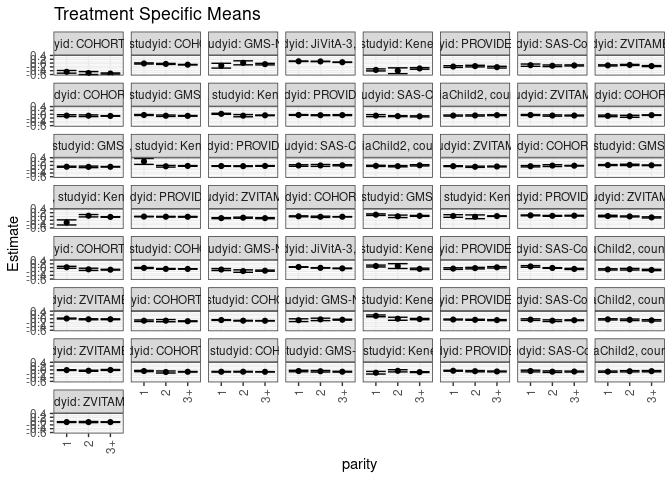

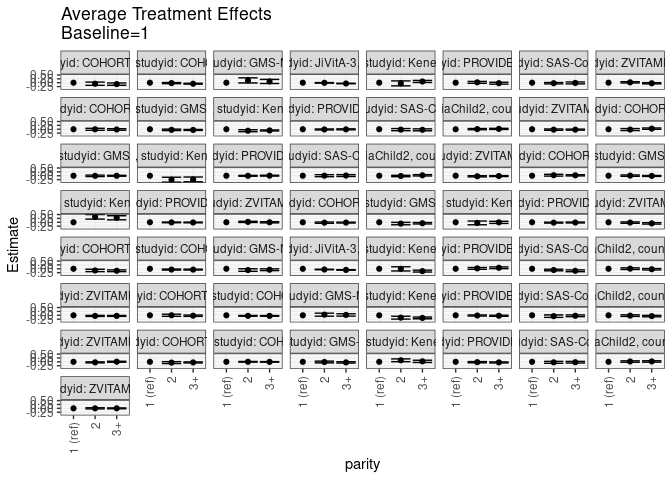

[figure not shown]

## Results Table

### Parameter: TSM

| agecat | studyid | country | intervention_level | baseline_level | estimate | ci_lower | ci_upper |
| --- | --- | --- | --- | --- | --- | --- | --- |
| 0-3 months | COHORTS | GUATEMALA | 1 | NA | -0.4603043 | -0.5293511 | -0.3912576 |
| 0-3 months | COHORTS | GUATEMALA | 2 | NA | -0.5255060 | -0.6023912 | -0.4486208 |
| 0-3 months | COHORTS | GUATEMALA | 3+ | NA | -0.5509915 | -0.5800002 | -0.5219828 |
| 0-3 months | COHORTS | INDIA | 1 | NA | -0.0206252 | -0.0487197 | 0.0074693 |
| 0-3 months | COHORTS | INDIA | 2 | NA | -0.0455879 | -0.0722753 | -0.0189004 |
| 0-3 months | COHORTS | INDIA | 3+ | NA | -0.0846688 | -0.0980140 | -0.0713236 |
| 0-3 months | GMS-Nepal | NEPAL | 1 | NA | -0.1382292 | -0.2644802 | -0.0119783 |
| 0-3 months | GMS-Nepal | NEPAL | 2 | NA | 0.0125334 | -0.0918219 | 0.1168888 |
| 0-3 months | GMS-Nepal | NEPAL | 3+ | NA | -0.0569111 | -0.0964969 | -0.0173254 |
| 0-3 months | JiVitA-3 | BANGLADESH | 1 | NA | 0.0935946 | 0.0821053 | 0.1050840 |
| 0-3 months | JiVitA-3 | BANGLADESH | 2 | NA | 0.0859631 | 0.0752083 | 0.0967179 |
| 0-3 months | JiVitA-3 | BANGLADESH | 3+ | NA | 0.0440454 | 0.0327534 | 0.0553373 |
| 0-3 months | Keneba | GAMBIA | 1 | NA | -0.3601136 | -0.4127969 | -0.3074303 |
| 0-3 months | Keneba | GAMBIA | 2 | NA | -0.4029456 | -0.5541133 | -0.2517779 |
| 0-3 months | Keneba | GAMBIA | 3+ | NA | -0.2817945 | -0.3218333 | -0.2417557 |
| 0-3 months | PROVIDE | BANGLADESH | 1 | NA | -0.1830037 | -0.2277956 | -0.1382118 |
| 0-3 months | PROVIDE | BANGLADESH | 2 | NA | -0.1598731 | -0.2001991 | -0.1195470 |
| 0-3 months | PROVIDE | BANGLADESH | 3+ | NA | -0.2149368 | -0.2597333 | -0.1701403 |
| 0-3 months | SAS-CompFeed | INDIA | 1 | NA | -0.1105925 | -0.1697200 | -0.0514650 |
| 0-3 months | SAS-CompFeed | INDIA | 2 | NA | -0.1417653 | -0.1830005 | -0.1005301 |
| 0-3 months | SAS-CompFeed | INDIA | 3+ | NA | -0.1248953 | -0.1523849 | -0.0974057 |
| 0-3 months | ZVITAMBO | ZIMBABWE | 1 | NA | -0.1218265 | -0.1508017 | -0.0928513 |
| 0-3 months | ZVITAMBO | ZIMBABWE | 2 | NA | -0.0982707 | -0.1244455 | -0.0720959 |
| 0-3 months | ZVITAMBO | ZIMBABWE | 3+ | NA | -0.1577906 | -0.1842897 | -0.1312915 |
| 3-6 months | COHORTS | GUATEMALA | 1 | NA | 0.0200501 | -0.0312706 | 0.0713707 |
| 3-6 months | COHORTS | GUATEMALA | 2 | NA | -0.0875965 | -0.1441860 | -0.0310070 |
| 3-6 months | COHORTS | GUATEMALA | 3+ | NA | -0.1078373 | -0.1288430 | -0.0868316 |
| 3-6 months | COHORTS | INDIA | 1 | NA | -0.0153032 | -0.0419037 | 0.0112973 |
| 3-6 months | COHORTS | INDIA | 2 | NA | -0.0656987 | -0.0847471 | -0.0466503 |
| 3-6 months | COHORTS | INDIA | 3+ | NA | -0.0680635 | -0.0794290 | -0.0566980 |

[output cut: 141 more lines]

### Parameter: E(Y)

| agecat | studyid | country | intervention_level | baseline_level | estimate | ci_lower | ci_upper |
| --- | --- | --- | --- | --- | --- | --- | --- |
| 0-3 months | COHORTS | GUATEMALA | NA | NA | -0.5371921 | -0.5589495 | -0.5154346 |
| 0-3 months | COHORTS | INDIA | NA | NA | -0.0677269 | -0.0765502 | -0.0589035 |
| 0-3 months | GMS-Nepal | NEPAL | NA | NA | -0.0317680 | -0.0569509 | -0.0065852 |
| 0-3 months | JiVitA-3 | BANGLADESH | NA | NA | 0.0740557 | 0.0691191 | 0.0789922 |
| 0-3 months | Keneba | GAMBIA | NA | NA | -0.2821028 | -0.3073160 | -0.2568895 |
| 0-3 months | PROVIDE | BANGLADESH | NA | NA | -0.1880402 | -0.2054115 | -0.1706689 |
| 0-3 months | SAS-CompFeed | INDIA | NA | NA | -0.1273566 | -0.1543372 | -0.1003761 |
| 0-3 months | ZVITAMBO | ZIMBABWE | NA | NA | -0.1402688 | -0.1504985 | -0.1300391 |
| 3-6 months | COHORTS | GUATEMALA | NA | NA | -0.0963382 | -0.1109683 | -0.0817082 |
| 3-6 months | COHORTS | INDIA | NA | NA | -0.0633737 | -0.0703095 | -0.0564379 |
| 3-6 months | GMS-Nepal | NEPAL | NA | NA | -0.1613977 | -0.1800128 | -0.1427826 |
| 3-6 months | JiVitA-3 | BANGLADESH | NA | NA | -0.0034426 | -0.0083086 | 0.0014234 |
| 3-6 months | Keneba | GAMBIA | NA | NA | -0.0278645 | -0.0482582 | -0.0074707 |
| 3-6 months | PROVIDE | BANGLADESH | NA | NA | -0.0269625 | -0.0428628 | -0.0110622 |
| 3-6 months | SAS-CompFeed | INDIA | NA | NA | -0.0166348 | -0.0360336 | 0.0027639 |
| 3-6 months | TanzaniaChild2 | TANZANIA, UNITED REPUBLIC OF | NA | NA | -0.0841486 | -0.1008599 | -0.0674373 |
| 3-6 months | ZVITAMBO | ZIMBABWE | NA | NA | -0.0012924 | -0.0104920 | 0.0079073 |
| 6-9 months | COHORTS | GUATEMALA | NA | NA | -0.1207546 | -0.1326448 | -0.1088643 |
| 6-9 months | COHORTS | INDIA | NA | NA | -0.0985796 | -0.1048064 | -0.0923527 |
| 6-9 months | GMS-Nepal | NEPAL | NA | NA | -0.0438931 | -0.0614010 | -0.0263853 |
| 6-9 months | Keneba | GAMBIA | NA | NA | -0.0045762 | -0.0287122 | 0.0195598 |
| 6-9 months | PROVIDE | BANGLADESH | NA | NA | -0.0614264 | -0.0722690 | -0.0505838 |
| 6-9 months | SAS-CompFeed | INDIA | NA | NA | -0.0823482 | -0.0898643 | -0.0748321 |
| 6-9 months | TanzaniaChild2 | TANZANIA, UNITED REPUBLIC OF | NA | NA | -0.0525285 | -0.0687206 | -0.0363364 |
| 6-9 months | ZVITAMBO | ZIMBABWE | NA | NA | -0.0315646 | -0.0399465 | -0.0231828 |
| 9-12 months | COHORTS | GUATEMALA | NA | NA | -0.0887143 | -0.0986894 | -0.0787393 |
| 9-12 months | COHORTS | INDIA | NA | NA | -0.0933036 | -0.0995020 | -0.0871051 |
| 9-12 months | GMS-Nepal | NEPAL | NA | NA | -0.0798239 | -0.0934194 | -0.0662284 |
| 9-12 months | Keneba | GAMBIA | NA | NA | -0.1061496 | -0.1248815 | -0.0874176 |
| 9-12 months | PROVIDE | BANGLADESH | NA | NA | -0.0630470 | -0.0740183 | -0.0520757 |
| 9-12 months | SAS-CompFeed | INDIA | NA | NA | -0.0811963 | -0.0946758 | -0.0677169 |
| 9-12 months | TanzaniaChild2 | TANZANIA, UNITED REPUBLIC OF | NA | NA | -0.0652640 | -0.0796167 | -0.0509113 |
| 9-12 months | ZVITAMBO | ZIMBABWE | NA | NA | -0.0590759 | -0.0665312 | -0.0516205 |
| 12-15 months | COHORTS | GUATEMALA | NA | NA | -0.0875200 | -0.0977014 | -0.0773386 |
| 12-15 months | GMS-Nepal | NEPAL | NA | NA | -0.0667249 | -0.0775841 | -0.0558657 |
| 12-15 months | Keneba | GAMBIA | NA | NA | -0.0554331 | -0.0683830 | -0.0424832 |
| 12-15 months | PROVIDE | BANGLADESH | NA | NA | -0.0409107 | -0.0510053 | -0.0308161 |
| 12-15 months | SAS-CompFeed | INDIA | NA | NA | -0.0847390 | -0.0988912 | -0.0705868 |
| 12-15 months | TanzaniaChild2 | TANZANIA, UNITED REPUBLIC OF | NA | NA | -0.0649105 | -0.0794330 | -0.0503881 |
| 12-15 months | ZVITAMBO | ZIMBABWE | NA | NA | -0.0622748 | -0.0728257 | -0.0517239 |
| 15-18 months | COHORTS | GUATEMALA | NA | NA | -0.0545580 | -0.0655035 | -0.0436124 |
| 15-18 months | GMS-Nepal | NEPAL | NA | NA | -0.0689576 | -0.0815283 | -0.0563869 |
| 15-18 months | Keneba | GAMBIA | NA | NA | -0.0289062 | -0.0415733 | -0.0162391 |
| 15-18 months | PROVIDE | BANGLADESH | NA | NA | -0.0376437 | -0.0463882 | -0.0288992 |
| 15-18 months | SAS-CompFeed | INDIA | NA | NA | -0.0117156 | -0.0214328 | -0.0019983 |
| 15-18 months | TanzaniaChild2 | TANZANIA, UNITED REPUBLIC OF | NA | NA | -0.0189489 | -0.0345324 | -0.0033654 |
| 15-18 months | ZVITAMBO | ZIMBABWE | NA | NA | -0.0623481 | -0.0733140 | -0.0513822 |
| 18-21 months | COHORTS | GUATEMALA | NA | NA | -0.0194829 | -0.0293542 | -0.0096117 |
| 18-21 months | GMS-Nepal | NEPAL | NA | NA | 0.0155926 | 0.0038526 | 0.0273327 |
| 18-21 months | Keneba | GAMBIA | NA | NA | -0.0220748 | -0.0349179 | -0.0092317 |
| 18-21 months | PROVIDE | BANGLADESH | NA | NA | -0.0109399 | -0.0190984 | -0.0027814 |
| 18-21 months | ZVITAMBO | ZIMBABWE | NA | NA | -0.0689095 | -0.0806852 | -0.0571338 |
| 21-24 months | COHORTS | GUATEMALA | NA | NA | -0.0058090 | -0.0136683 | 0.0020502 |
| 21-24 months | GMS-Nepal | NEPAL | NA | NA | 0.0481269 | 0.0325947 | 0.0636591 |
| 21-24 months | Keneba | GAMBIA | NA | NA | 0.0194181 | 0.0072915 | 0.0315446 |
| 21-24 months | PROVIDE | BANGLADESH | NA | NA | 0.0462342 | 0.0375872 | 0.0548812 |
| 21-24 months | ZVITAMBO | ZIMBABWE | NA | NA | 0.0172279 | 0.0047469 | 0.0297089 |

### Parameter: ATE

| agecat | studyid | country | intervention_level | baseline_level | estimate | ci_lower | ci_upper |
| --- | --- | --- | --- | --- | --- | --- | --- |
| 0-3 months | COHORTS | GUATEMALA | 1 | 1 | 0.0000000 | 0.0000000 | 0.0000000 |
| 0-3 months | COHORTS | GUATEMALA | 2 | 1 | -0.0652017 | -0.1685876 | 0.0381841 |
| 0-3 months | COHORTS | GUATEMALA | 3+ | 1 | -0.0906872 | -0.1653176 | -0.0160568 |
| 0-3 months | COHORTS | INDIA | 1 | 1 | 0.0000000 | 0.0000000 | 0.0000000 |
| 0-3 months | COHORTS | INDIA | 2 | 1 | -0.0249626 | -0.0637121 | 0.0137868 |
| 0-3 months | COHORTS | INDIA | 3+ | 1 | -0.0640436 | -0.0951231 | -0.0329640 |
| 0-3 months | GMS-Nepal | NEPAL | 1 | 1 | 0.0000000 | 0.0000000 | 0.0000000 |
| 0-3 months | GMS-Nepal | NEPAL | 2 | 1 | 0.1507627 | -0.0140106 | 0.3155360 |
| 0-3 months | GMS-Nepal | NEPAL | 3+ | 1 | 0.0813181 | -0.0507977 | 0.2134340 |
| 0-3 months | JiVitA-3 | BANGLADESH | 1 | 1 | 0.0000000 | 0.0000000 | 0.0000000 |
| 0-3 months | JiVitA-3 | BANGLADESH | 2 | 1 | -0.0076316 | -0.0226807 | 0.0074176 |
| 0-3 months | JiVitA-3 | BANGLADESH | 3+ | 1 | -0.0495493 | -0.0657692 | -0.0333293 |
| 0-3 months | Keneba | GAMBIA | 1 | 1 | 0.0000000 | 0.0000000 | 0.0000000 |
| 0-3 months | Keneba | GAMBIA | 2 | 1 | -0.0428320 | -0.2025983 | 0.1169342 |
| 0-3 months | Keneba | GAMBIA | 3+ | 1 | 0.0783191 | 0.0123081 | 0.1443301 |
| 0-3 months | PROVIDE | BANGLADESH | 1 | 1 | 0.0000000 | 0.0000000 | 0.0000000 |
| 0-3 months | PROVIDE | BANGLADESH | 2 | 1 | 0.0231306 | -0.0373391 | 0.0836004 |
| 0-3 months | PROVIDE | BANGLADESH | 3+ | 1 | -0.0319331 | -0.0954203 | 0.0315540 |
| 0-3 months | SAS-CompFeed | INDIA | 1 | 1 | 0.0000000 | 0.0000000 | 0.0000000 |
| 0-3 months | SAS-CompFeed | INDIA | 2 | 1 | -0.0311728 | -0.0765652 | 0.0142196 |
| 0-3 months | SAS-CompFeed | INDIA | 3+ | 1 | -0.0143028 | -0.0756047 | 0.0469990 |
| 0-3 months | ZVITAMBO | ZIMBABWE | 1 | 1 | 0.0000000 | 0.0000000 | 0.0000000 |
| 0-3 months | ZVITAMBO | ZIMBABWE | 2 | 1 | 0.0235558 | -0.0154314 | 0.0625430 |
| 0-3 months | ZVITAMBO | ZIMBABWE | 3+ | 1 | -0.0359641 | -0.0751892 | 0.0032610 |
| 3-6 months | COHORTS | GUATEMALA | 1 | 1 | 0.0000000 | 0.0000000 | 0.0000000 |
| 3-6 months | COHORTS | GUATEMALA | 2 | 1 | -0.1076466 | -0.1840254 | -0.0312678 |
| 3-6 months | COHORTS | GUATEMALA | 3+ | 1 | -0.1278874 | -0.1833536 | -0.0724211 |
| 3-6 months | COHORTS | INDIA | 1 | 1 | 0.0000000 | 0.0000000 | 0.0000000 |
| 3-6 months | COHORTS | INDIA | 2 | 1 | -0.0503955 | -0.0830924 | -0.0176987 |
| 3-6 months | COHORTS | INDIA | 3+ | 1 | -0.0527603 | -0.0817000 | -0.0238206 |

[output cut: 141 more lines]

### Parameter: PAR

| agecat | studyid | country | intervention_level | baseline_level | estimate | ci_lower | ci_upper |
| --- | --- | --- | --- | --- | --- | --- | --- |
| 0-3 months | COHORTS | GUATEMALA | 1 | NA | -0.0768878 | -0.1445047 | -0.0092709 |
| 0-3 months | COHORTS | INDIA | 1 | NA | -0.0471016 | -0.0742448 | -0.0199585 |
| 0-3 months | GMS-Nepal | NEPAL | 1 | NA | 0.1064612 | -0.0145533 | 0.2274757 |
| 0-3 months | JiVitA-3 | BANGLADESH | 1 | NA | -0.0195390 | -0.0302134 | -0.0088646 |
| 0-3 months | Keneba | GAMBIA | 1 | NA | 0.0780108 | 0.0237331 | 0.1322885 |
| 0-3 months | PROVIDE | BANGLADESH | 1 | NA | -0.0050365 | -0.0454639 | 0.0353908 |
| 0-3 months | SAS-CompFeed | INDIA | 1 | NA | -0.0167641 | -0.0664200 | 0.0328918 |
| 0-3 months | ZVITAMBO | ZIMBABWE | 1 | NA | -0.0184423 | -0.0456501 | 0.0087655 |
| 3-6 months | COHORTS | GUATEMALA | 1 | NA | -0.1163883 | -0.1670067 | -0.0657700 |
| 3-6 months | COHORTS | INDIA | 1 | NA | -0.0480705 | -0.0735760 | -0.0225649 |
| 3-6 months | GMS-Nepal | NEPAL | 1 | NA | -0.0624740 | -0.1100138 | -0.0149342 |
| 3-6 months | JiVitA-3 | BANGLADESH | 1 | NA | -0.0380411 | -0.0502934 | -0.0257888 |
| 3-6 months | Keneba | GAMBIA | 1 | NA | -0.1141651 | -0.1621048 | -0.0662254 |
| 3-6 months | PROVIDE | BANGLADESH | 1 | NA | 0.0226019 | -0.0161079 | 0.0613117 |
| 3-6 months | SAS-CompFeed | INDIA | 1 | NA | -0.0795625 | -0.1179218 | -0.0412033 |
| 3-6 months | TanzaniaChild2 | TANZANIA, UNITED REPUBLIC OF | 1 | NA | 0.0072320 | -0.0218014 | 0.0362654 |
| 3-6 months | ZVITAMBO | ZIMBABWE | 1 | NA | -0.0158117 | -0.0359850 | 0.0043616 |
| 6-9 months | COHORTS | GUATEMALA | 1 | NA | -0.0189304 | -0.0568073 | 0.0189464 |
| 6-9 months | COHORTS | INDIA | 1 | NA | -0.0331724 | -0.0522954 | -0.0140494 |
| 6-9 months | GMS-Nepal | NEPAL | 1 | NA | 0.0290196 | -0.0399980 | 0.0980372 |
| 6-9 months | Keneba | GAMBIA | 1 | NA | -0.1589335 | -0.2062242 | -0.1116428 |
| 6-9 months | PROVIDE | BANGLADESH | 1 | NA | -0.0222244 | -0.0422855 | -0.0021633 |
| 6-9 months | SAS-CompFeed | INDIA | 1 | NA | -0.0385437 | -0.0806746 | 0.0035872 |
| 6-9 months | TanzaniaChild2 | TANZANIA, UNITED REPUBLIC OF | 1 | NA | -0.0226942 | -0.0515855 | 0.0061971 |
| 6-9 months | ZVITAMBO | ZIMBABWE | 1 | NA | -0.0227988 | -0.0416607 | -0.0039369 |
| 9-12 months | COHORTS | GUATEMALA | 1 | NA | -0.0312141 | -0.0608670 | -0.0015611 |
| 9-12 months | COHORTS | INDIA | 1 | NA | 0.0019307 | -0.0148476 | 0.0187090 |
| 9-12 months | GMS-Nepal | NEPAL | 1 | NA | -0.0224384 | -0.0605263 | 0.0156496 |
| 9-12 months | Keneba | GAMBIA | 1 | NA | 0.0401536 | -0.0289563 | 0.1092635 |
| 9-12 months | PROVIDE | BANGLADESH | 1 | NA | -0.0200741 | -0.0417620 | 0.0016138 |
| 9-12 months | SAS-CompFeed | INDIA | 1 | NA | -0.0220789 | -0.0636379 | 0.0194801 |
| 9-12 months | TanzaniaChild2 | TANZANIA, UNITED REPUBLIC OF | 1 | NA | 0.0234638 | -0.0036265 | 0.0505541 |
| 9-12 months | ZVITAMBO | ZIMBABWE | 1 | NA | -0.0064089 | -0.0266177 | 0.0137999 |
| 12-15 months | COHORTS | GUATEMALA | 1 | NA | -0.0136781 | -0.0591127 | 0.0317564 |
| 12-15 months | GMS-Nepal | NEPAL | 1 | NA | -0.0254294 | -0.0511197 | 0.0002610 |
| 12-15 months | Keneba | GAMBIA | 1 | NA | -0.0748155 | -0.1040365 | -0.0455946 |
| 12-15 months | PROVIDE | BANGLADESH | 1 | NA | -0.0025370 | -0.0210016 | 0.0159276 |
| 12-15 months | SAS-CompFeed | INDIA | 1 | NA | -0.0095794 | -0.0573585 | 0.0381997 |
| 12-15 months | TanzaniaChild2 | TANZANIA, UNITED REPUBLIC OF | 1 | NA | 0.0064762 | -0.0176350 | 0.0305875 |
| 12-15 months | ZVITAMBO | ZIMBABWE | 1 | NA | -0.0206467 | -0.0451940 | 0.0039007 |
| 15-18 months | COHORTS | GUATEMALA | 1 | NA | 0.0327294 | -0.0051333 | 0.0705921 |
| 15-18 months | GMS-Nepal | NEPAL | 1 | NA | 0.0040280 | -0.0225307 | 0.0305867 |
| 15-18 months | Keneba | GAMBIA | 1 | NA | -0.2350435 | -0.3852115 | -0.0848755 |
| 15-18 months | PROVIDE | BANGLADESH | 1 | NA | -0.0018440 | -0.0176300 | 0.0139420 |
| 15-18 months | SAS-CompFeed | INDIA | 1 | NA | -0.0039965 | -0.0458212 | 0.0378282 |
| 15-18 months | TanzaniaChild2 | TANZANIA, UNITED REPUBLIC OF | 1 | NA | 0.0076623 | -0.0169096 | 0.0322342 |
| 15-18 months | ZVITAMBO | ZIMBABWE | 1 | NA | -0.0210714 | -0.0426720 | 0.0005292 |
| 18-21 months | COHORTS | GUATEMALA | 1 | NA | 0.0266105 | -0.0072746 | 0.0604955 |
| 18-21 months | GMS-Nepal | NEPAL | 1 | NA | 0.0002354 | -0.0253041 | 0.0257749 |
| 18-21 months | Keneba | GAMBIA | 1 | NA | 0.2894529 | 0.1605629 | 0.4183429 |
| 18-21 months | PROVIDE | BANGLADESH | 1 | NA | -0.0078850 | -0.0195012 | 0.0037312 |
| 18-21 months | ZVITAMBO | ZIMBABWE | 1 | NA | 0.0160024 | -0.0079417 | 0.0399465 |
| 21-24 months | COHORTS | GUATEMALA | 1 | NA | -0.0156325 | -0.0394236 | 0.0081586 |
| 21-24 months | GMS-Nepal | NEPAL | 1 | NA | -0.0470557 | -0.0855196 | -0.0085919 |
| 21-24 months | Keneba | GAMBIA | 1 | NA | -0.0065578 | -0.0729262 | 0.0598106 |
| 21-24 months | PROVIDE | BANGLADESH | 1 | NA | -0.0127624 | -0.0309898 | 0.0054650 |
| 21-24 months | ZVITAMBO | ZIMBABWE | 1 | NA | -0.0072207 | -0.0406785 | 0.0262370 |